# Practical 3: pivotting and facetting

# Introduction

In this practical, you will learn how to manipulate your data in such a way that it can easy be visualised and how to make many plots at once using ‘ggplot’.

You will analyse data collected from 20 different veterinarian clinics. However, this data is not tidy yet, which is often the case when you work with real life data. To prepare the data for analysis, you will use ‘tidyr’, which is also part of the ‘tidyverse’ package. The dataset needed can be downloaded HERE.

# What is tidy data?

When visualising data using ‘ggplot’, it is of great importance that the dataset is structured in consistent manner, because it saves you a lot of time in the long run. To make a dataset tidy, it has to meet 3 rules: * Each variable must have its own column. * Each observation must have its own row. * Each value must have its own cell.

You can read more on tidy data and its advantages [here](https://r4ds.had.co.nz/tidy-data.html).

1. **Read the data into R and load the tidyverse package.**

```r
library(tidyverse)
dat <- read.csv('vet.data.csv')
```

# Tidy the data

Now you’ve imported the data, you can check what it looks like.

```r
# Get an idea of what the vet dataset looks like
head(dat)
```

|  | clinic | client | type | gen_age | breed | food_quality | area | value2017 | value2018 |
| --- | --- | --- | --- | --- | --- | --- | --- | --- | --- |
| 1 | 1 | 1 | weight | F_15 | Persian | II | suburban | 7.8 | 8.0 |
| 2 | 1 | 1 | BMI | F_15 | Persian | II | suburban | 26.0 | 22.0 |
| 3 | 1 | 2 | weight | M_10 | Persian | II | suburban | 13.7 | 14.6 |
| 4 | 1 | 2 | BMI | M_10 | Persian | II | suburban | 35.0 | 30.0 |
| 5 | 1 | 3 | weight | F_14 | Burmese | II | suburban | 6.3 | 6.6 |
| 6 | 1 | 3 | BMI | F_14 | Burmese | II | suburban | 24.0 | 20.0 |

As you can see, the dataset at hand isn’t tidy yet.

2. **List the thing that need to be changed to make this dataset tidy, it may help to draw out a tidy format on a piece of paper.**

```r
# Weight and BMI are 2 variables -> there should be a column for weight and one for BMI

# There are 2 observations per client (2017 & 2018) -> each year should get its own row, year should be a variable (with its own column) to indicate wheter the row displays observations mage in 2017 or 2018.

# Gen_age is a column where two pieces of information (gender and age) share a cell, these should be splitted up into two different columns.
```

The function ‘pivot_longer()’ from the ‘tidyr’ package is a neat function that can be used to easily manipulate data structured in a wide format into a long format.

3. **Use ‘pivot_longer()’ to restructure the data such that the data from 2017 and 2018 are no longer in two different columns, but with year as a variable indicating when the data is collected. You can use ‘mutate()’ in combination with ‘str_remove()’ to get rid of the 'value' part.**

```r
dat <- dat %>%
  pivot_longer(cols = c(value2017, value2018), names_to = 'year', values_to = 'count') %>%
  mutate(year = str_remove(year, "value"))
```

The function ‘pivot_wider’ can be used to transform data structured in a long format into a wide format.

4. **Use ‘pivot_wider’ to restructure the data so that weight and BMI get their own column.**

```r
dat <- dat %>%
  pivot_wider(names_from = type, values_from = count)
```

In this dataset, both gender and age are displayed in the same column and cell. The ‘separate()’ fuction can be used to split information in displayed in one column into two separate columns.

5. **Use ‘separate()’ to make a separate cloumn for age and one for gender.**

```r
dat <- dat %>%
  separate(col = gen_age, into = c('gender', 'age'))
```

To properly analyse the data, every observation needs to have its own, unique, identifier.

6. **Check whether each row in this dataset has a unique identifier, if not, assign one. Tip: ‘unite()’ can be usefull if you want to combine information from two different cells into one cell.**

```r
dat <- dat %>%
  unite(col = ID, clinic, client, remove = FALSE)
```

7. **Check whether your data is tidy now.**

```r
head(dat)
```

| ID | clinic | client | gender | age | breed | food_quality | area | year | weight | BMI |
| --- | --- | --- | --- | --- | --- | --- | --- | --- | --- | --- |
| 1_1 | 1 | 1 | F | 15 | Persian | II | suburban | 2017 | 7.8 | 26 |
| 1_1 | 1 | 1 | F | 15 | Persian | II | suburban | 2018 | 8.0 | 22 |
| 1_2 | 1 | 2 | M | 10 | Persian | II | suburban | 2017 | 13.7 | 35 |
| 1_2 | 1 | 2 | M | 10 | Persian | II | suburban | 2018 | 14.6 | 30 |
| 1_3 | 1 | 3 | F | 14 | Burmese | II | suburban | 2017 | 6.3 | 24 |
| 1_3 | 1 | 3 | F | 14 | Burmese | II | suburban | 2018 | 6.6 | 20 |

If all steps are performed correct, you should have a tidy dataset now. However, coding every step separatly is quite timeconsuming. It would be faster and more in the spirit of the ‘tidyverse’ package to code all steps at once using pipes.

8. **Reload the data and tidy it again, but now using pipes.**

```r
dat <- read.csv('vet.data.csv')

dat <- dat %>%
  pivot_longer(cols = c(value2017, value2018), names_to = 'year', values_to = 'count') %>%
  mutate(year = str_remove(year, "value")) %>%
  pivot_wider(names_from = type, values_from = count) %>%
  separate(col = gen_age, into = c('gender', 'age')) %>%
  unite(col = ID, clinic, client, remove = FALSE) %>%
  mutate(age = as.numeric(age))
```

# Analysis and visualisation

9. **Visualise the distribution of breed, food quality and and area.**

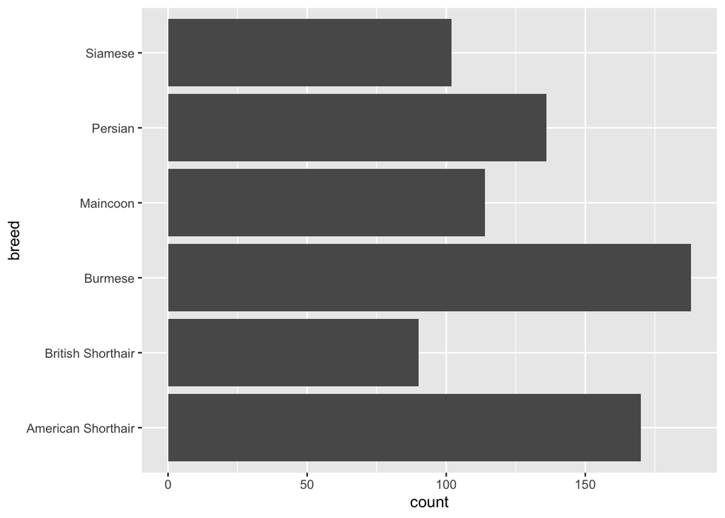

```r
ggplot(data = dat) +
  geom_bar(aes(x = breed)) +
  coord_flip()
```

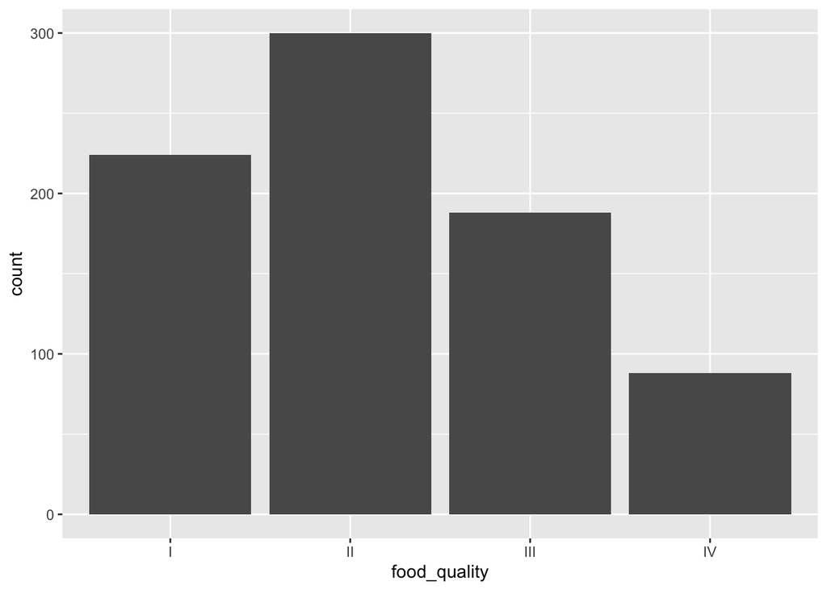

```r
ggplot(data = dat) +
  geom_bar(aes(x = food_quality))
```

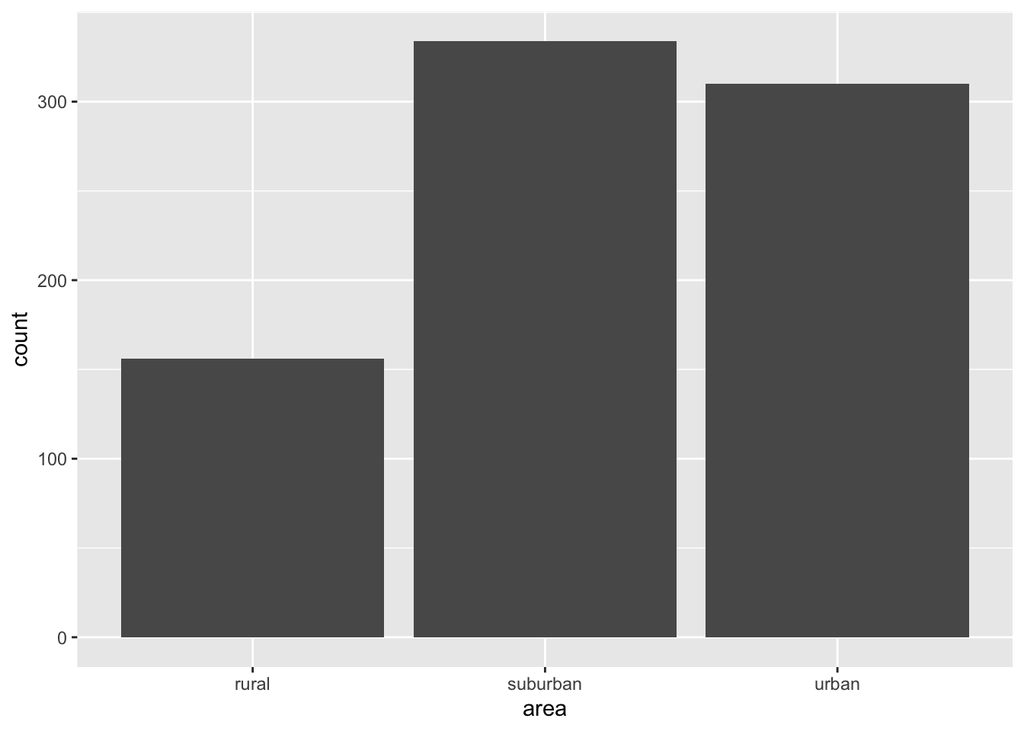

```r
ggplot(data = dat) +
  geom_bar(aes(x = area))
```

10. **Visualise the distribution of weight, conditional on breed using ‘facet_wrap()’.**

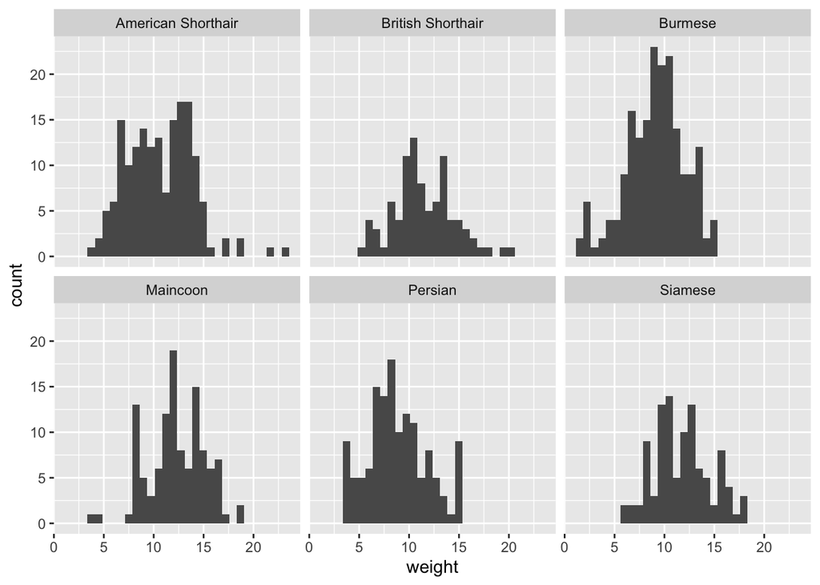

```r
ggplot(data = dat) +
  geom_histogram(aes(x = weight)) +
  facet_wrap(~breed)
```

11. **Use ‘geom_boxplot()’ in combination with ‘facet_wrap()’ to check if there are any outliers in the data.**

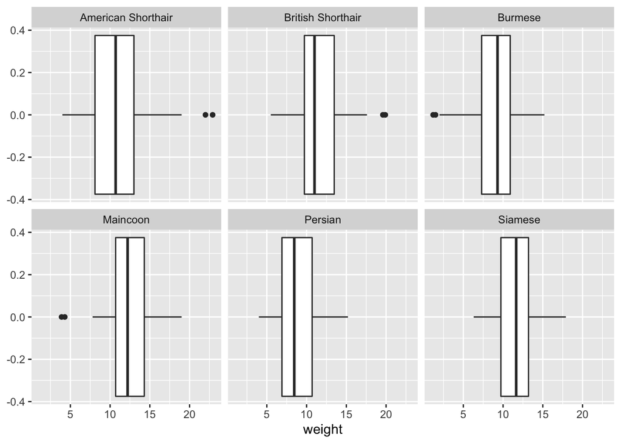

```r
ggplot(data = dat) +
  geom_boxplot(aes(x = weight)) +
  facet_wrap(~breed)
```

12. **Assume that weights below 3 lbs or above 20 lbs are the result of a mistake made at the data input, replace these values with NA. Which cases are affected by this decision?**

```r
dat %>%
  filter(weight < 3 | weight > 20) %>%
  select(ID)
```

| ID |
| --- |
| 4_20 |
| 4_20 |
| 5_16 |
| 7_16 |
| 7_16 |
| 9_12 |
| 9_12 |
| 13_17 |
| 13_17 |
| 17_20 |

[output cut: 1 more lines]

```r
# Cats with ID's 4_20, 5_16, 7_16, 9_12, 13_17 and 17_20

# You can also use which(dat$weight).
which(dat$weight < 3)
```

```
## [1] 159 160 191 271 272 343 344 513 514
```

```r
which(dat$weight > 20)
```

```
## [1] 679 680
```

```r
# Filtering all cases with a weight between 3 and 20 lbs.
dat <- dat %>%
  mutate(weight = replace(weight, weight < 3, NA)) %>%
  mutate(weight = replace(weight, weight > 20, NA))
```

13. **What is the mean weight for each breed? Use ‘group_by()’ in combination with ‘summarise()’.**

```r
dat %>%
  group_by(breed) %>%
  summarise(mean = mean(weight, na.rm = TRUE))
```

| breed | mean |
| --- | --- |
| American Shorthair | 10.497619 |
| British Shorthair | 11.456667 |
| Burmese | 9.496648 |
| Maincoon | 12.332456 |
| Persian | 8.869853 |
| Siamese | 11.756863 |

14. **Visualise the relationship between age and weight, add a regressionline to your plot using ‘geom_smooth()’. Are weight and age related?**

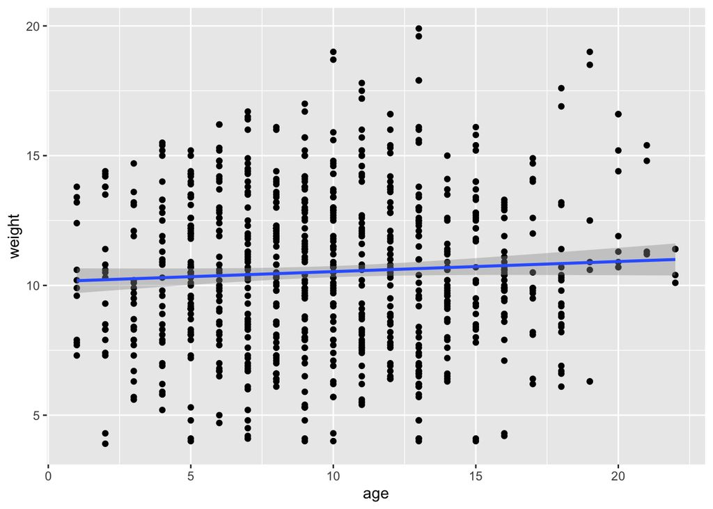

```r
dat %>%
  ggplot(aes(x = age, y = weight)) +
  geom_point() +
  geom_smooth(method = 'lm')
```

15. **Use ‘facet_grid()’ make the same visualisation, but now conditioning on breed and area. How does this alter your conclusion?**

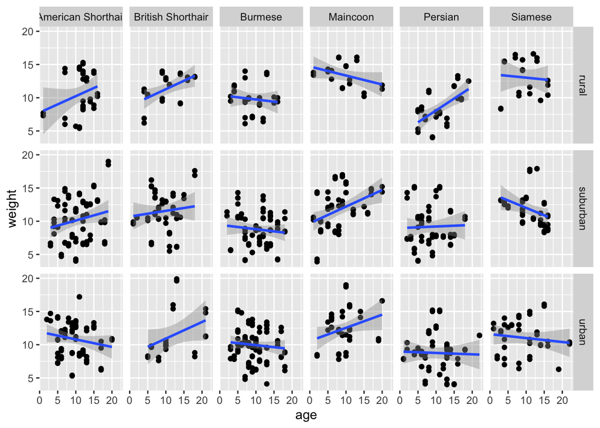

```r
dat %>%
  ggplot(aes(x = age, y = weight)) +
  geom_point() +
  geom_smooth(method = 'lm') +
  facet_grid(area ~ breed)
```

16. **Based on the visualisations made for question 15 and 16, can you draw the conclusion that individual cats don’t weigh more as they get older? Explain your answer.**

```r
# No, you can't. Even though there is no clear correlation between weight and age on group level (all cats), this doesn't mean that there is no relation between age and weight on an individual level (1 cat). Deducing inferences about the individual from inferences about the group is known under the term *ecological fallacy*.
```

17. **To get an idea if cats tend to weigh more as they get older on an individual level, you could compare the weight of each cat in 2017 and 2018 on an individual level. In how many percent of the cases did cats gain weight over the year?**

```r
mean(dat %>%
  filter(year == 2017) %>%
  select(weight) <
    dat %>%
      filter(year == 2018) %>%
      select(weight), na.rm = TRUE)
```

```
## [1] 0.8781726
```

```r
# 87.8% of the cats weigh more in 2018 than they did in 2017.
```